# Homework 4

Author

Affiliation

Kevin Silberberg

University of California Santa Cruz

Published

November 7, 2024

# Question 1

Consider the system of SDEs

$$\begin{cases}dX(t;\omega) &= -X(t;\omega)^3dt + dY(t;\omega) \\dY(t;\omega) &= -\tau Y(t;\omega)dt + \sigma dW(t;\omega)\end{cases} \tag{1}$$

where $\sigma, \tau \leq 0$ are given parameters and $W(t;\omega)$ is a Wiener process. The initial condition $(X(0;\omega), Y(0;\omega))$ has i.i.d. components both of which are uniformly distributed in $[0, 1]$, i.e., $X(0;\omega)$ and $Y(0;\omega)$ are independent random variables with uniform PDF in $[0,1]$.

## Part A

Plot a few sample paths of $X(t;\omega)$ for $\sigma = 0.1$ and $\tau = \{0.01, 1, 10\}$.

### Solution

We convert Equation 1 into a numerical simulation by first converting the SDE into a discrete time form via the Euler-Maruyama discretization.

We descritize a grid within the interval [0, T] into N equal parts, where $\Delta t = \frac{T}{N}$

Let us recursively define $Y_n$ for $0 \leq n \leq N-1$

$$\begin{align}
Y_{n+1} = Y_n -\tau Y_n \Delta t + \sigma \Delta W
\end{align}$$

and $X_n$

$$\begin{align}
X_{n+1} = X_n - X_n^3 \Delta t + \Delta Y_n
\end{align}$$

where $\Delta Y_n = Y_{n+1} - Y_n = -\tau Y_n \Delta t + \sigma \Delta W_n$

where $\Delta W_n$ are i.i.d Gaussian random variables with zero mean and variance $\Delta t$.

```julia
using GLMakie
using Distributions

function partA(τ::Float64, σ::Float64)
    # define the length of subintervals
    Δt = 1e-4
    ts = 0.0:Δt:5.0
    # number of samples
    N = 5
    # Weiner processs
    W = Normal(0, sqrt(Δt))
    # initialize mesh
    X = Matrix{Float64}(undef, length(ts), N)
    Y = Matrix{Float64}(undef, length(ts), N)

    # apply initial conditions
    for i in 1:N
        X[1, i] = rand()
        Y[1, i] = rand()
    end
    # propagate the process
    for i in 1:N
        for j in 2:length(ts)
            ΔW = rand(W)
            X[j, i] = X[j-1, i] - (X[j-1, i]^3)*Δt -τ*Y[j-1, i]*Δt + σ*ΔW
            Y[j, i] = Y[j-1, i] - τ*Y[j-1, i]*Δt + σ*ΔW
        end
    end
    # make the figure
    fig = Figure()
    ax = Axis(
        fig[1, 1],
        title = "σ = $σ τ = $τ",
        xlabel = "t",
        ylabel = L"$X_{n+1}$"
    )
    # set y axis limits
    ylims!(ax, -1.0, 1.0)

    # Plot the samples
    for i in 1:N
        lines!(ax, ts, X[:, i])
    end
    return fig
end
save("parta01.png", partA(0.01, 0.1))
save("parta1.png", partA(1.0, 0.1))
save("parta10.png", partA(10.0, 0.1))
```

[figure not shown]

$\tau = 0.01$

[figure not shown]

$\tau = 1.0$

[figure not shown]

$\tau = 10.0$

## Part B

Do you expect the system Equation 1 to have a statistically stationary state? Justify your answer.

### Solution

From part A, we can see that as we increase $\tau$, the system rapidly converges to a statistically steady-state process. We can prove this by the Kernel Density Estimation for 1000 sample paths for varying $\tau$ and comparing the estimated PDF for later times.

The solution approaches a statistically steady state as $t\rightarrow \infty$ and approaches the statisically steady state at the rate $\tau$. It seems though that the pdf for varying $\tau$ may not be the same, as $\tau = 10.0$ seems to have a bimodal distribution for later times.

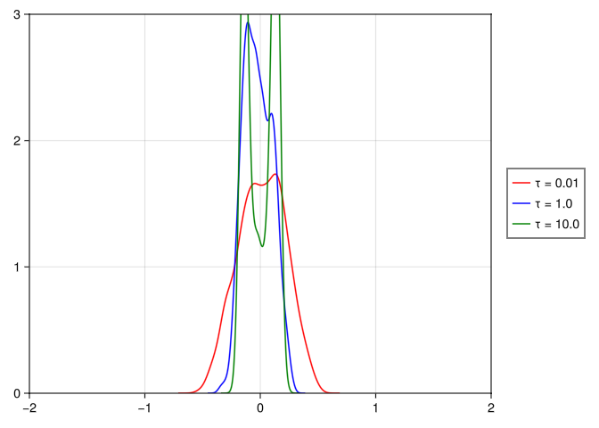

```julia
using KernelDensity

function simulateB(τ::Float64)
    σ = 0.1
    # define the length of subintervals
    Δt = 1e-4
    ts = 0.0:Δt:20.0
    # number of samples
    N = 1000
    # Weiner processs
    W = Normal(0, sqrt(Δt))
    # initialize mesh
    X = Matrix{Float64}(undef, length(ts), N)
    Y = Matrix{Float64}(undef, length(ts), N)

    # apply initial conditions
    for i in 1:N
        X[1, i] = rand()
        Y[1, i] = rand()
    end
    # propagate the process
    for i in 1:N
        for j in 2:length(ts)
            ΔW = rand(W)
            X[j, i] = X[j-1, i] - (X[j-1, i]^3)*Δt -τ*Y[j-1, i]*Δt + σ*ΔW
            Y[j, i] = Y[j-1, i] - τ*Y[j-1, i]*Δt + σ*ΔW
        end
    end
    return X, Y, length(ts)
end

function partB()
    X1, Y1, ts = simulateB(0.01)
    X2, Y2, _ = simulateB(1.0)
    X3, Y3, _ = simulateB(10.0)

    fig = Figure()
    ax = Axis(
        fig[1, 1]
    )
    ylims!(ax, 0.0, 3.0)
    xlims!(ax, -2.0, 2.0)

    d1 = kde(X1[1, :])
    d2 = kde(X2[1, :])
    d3 = kde(X3[1, :])
    kde_data1 = Observable((d1.x, d1.density))
    kde_data2 = Observable((d2.x, d2.density))
    kde_data3 = Observable((d3.x, d3.density))

    kde_line1 = lines!(ax, [0.0], [0.0], color = :red, label = "τ = 0.01")
    kde_line2 = lines!(ax, [0.0], [0.0], color = :blue, label = "τ = 1.0")
    kde_line3 = lines!(ax, [0.0], [0.0], color = :green, label = "τ = 10.0")

    kde_plot1 = lift(kde_data1) do (x, density)
        kde_line1[1] = x
        kde_line1[2] = density
    end
    kde_plot2 = lift(kde_data2) do (x, density)
        kde_line2[1] = x
        kde_line2[2] = density
    end
    kde_plot3 = lift(kde_data3) do (x, density)
        kde_line3[1] = x
        kde_line3[2] = density
    end

    Legend(fig[1, 2], ax)
    record(fig, "partb.mp4", 2:400:ts; framerate = 30) do k
        d1 = kde(X1[k, :])
        d2 = kde(X2[k, :])
        d3 = kde(X3[k, :])
        kde_data1[] = (d1.x, d1.density)
        kde_data2[] = (d2.x, d2.density)
        kde_data3[] = (d3.x, d3.density)
    end
    return fig
end
partB()
```

[video not shown]

## Part C

Write the Fokker-Planck equation for the joint PDF of $X(t;\omega)$ and $Y(t;\omega)$.

### Solution

Let us write Equation 1 in state-space form

$$\begin{align}
dX &= -X^3 dt - \tau Y dt + \sigma dW \\
dY &= -\tau Y dt + \sigma dW
\end{align}$$

The vector $\mathbf{G}(\mathbf{X}, t)$ can be written as

$$\begin{align}
\mathbf{G}(\mathbf{X}, t) &= \left[
\begin{matrix}
-X^3 - \tau Y \\
-\tau Y
\end{matrix}\right]
\end{align}$$

The matrix $\mathbf{S}$ can be written as

$$\begin{align}
\mathbf{S} = \left[
\begin{matrix}
\sigma \\
\sigma
\end{matrix}\right]
\end{align}$$

We can thus write the Fokker-Planck equation according equation 59 in course notes 4 as follows:

$$\begin{align}
\frac{\partial p(\mathbf{x}, t)}{\partial t} &= -\sum_{k=1}^{2} \frac{\partial}{\partial x_k} \left(G_k(\mathbf{x}, t) p(\mathbf{x})\right) + \frac{1}{2} \sum_{i, k = 1}^2 \frac{\partial^2}{\partial x_i \partial x_k}\left(\sum_{j=1}^2 S_{ij}(\mathbf{x}, t)S_{kj}(\mathbf{x}, t) p(\mathbf{x}, t) \right) \\
\frac{\partial p}{\partial t} &= -\left(\frac{\partial}{\partial x} \left((-x^3 -\tau y)p\right) + \frac{\partial}{\partial y}\left(-\tau yp\right)\right) + \frac{\sigma^2}{2}\left(\frac{\partial^2p}{\partial x^2} + \frac{\partial^2 p}{\partial y^2}\right) \\
&= \frac{\partial}{\partial x}(x^3 p) + \tau p + \tau y\left(\frac{\partial p}{\partial x} + \frac{\partial p}{\partial y}\right) + \frac{\sigma^2}{2}\left(\frac{\partial^2p}{\partial x^2} + \frac{\partial^2 p}{\partial y^2}\right)
\end{align}$$

The Fokker-Planck equation is thus

$$\frac{\partial p(x, y, t)}{\partial t} = \frac{\partial}{\partial x}(x^3 p(x, y, t)) + \tau p(x, y, t) + \tau y\left(\frac{\partial p(x, y, t)}{\partial x} + \frac{\partial p(x, y, t)}{\partial y}\right) + \frac{\sigma^2}{2}\left(\frac{\partial^2p(x, y, t)}{\partial x^2} + \frac{\partial^2 p(x, y, t)}{\partial y^2}\right) \tag{2}$$

where $p(x, y, t)$ is the joint PDF of $X$ and $Y$.

## Part D

Write the reduced-order equation for the joint PDF of $X(t;\omega)$ in terms of the conditional expectation $\mathbb{E}\{Y(t;\omega)|X(t;\omega)\}$.

### Solution

To obtain the reduced-order equation, let us integrate Equation 2 with respect to $y$ and use the definition of conditional PDF.

$$\begin{align}
\frac{\partial}{\partial t}\int_{-\infty}^{\infty}pdy &= \int_{-\infty}^{\infty}\left(\frac{\partial}{\partial x} \left((x^3 +\tau y)p\right) + \frac{\partial}{\partial y}\left(\tau yp\right) + \frac{\sigma^2}{2}\left(\frac{\partial^2p}{\partial x^2} + \frac{\partial^2 p}{\partial y^2}\right)\right) dy\\
\frac{\partial p(x,t)}{\partial t} &= \frac{\partial}{\partial x} \int_{-\infty}^{\infty}(x^3 + \tau y)p dy + \int_{-\infty}^{\infty} \frac{\partial}{\partial y}(\tau yp)dy + \frac{\sigma^2}{2}\left(\frac{\partial^2}{\partial x^2}\int_{-\infty}^{\infty}p dy + \cancelto{0}{\int_{-\infty}^{\infty}\frac{\partial^2 p}{\partial y^2}dy}\right) \\
&= \frac{\partial}{\partial x}\left(x^3p(x, t) + \tau p(x, t)\mathbb{E}\{Y | X\}\right) + \cancelto{0}{\tau y p_{\bigg{|}_{-\infty}^{\infty}}} + \frac{\sigma^2}{2}\frac{\partial^2 p(x, t)}{\partial x^2}\\
\end{align}$$

Thus, the reduced order equation for the joint PDF can be written as,

$$\frac{\partial p(x, t)}{\partial t} = \frac{\partial}{\partial x}(x^3 p(x, t)) + \tau \frac{\partial}{\partial x}\left(p(x, t)\mathbb{E}\{y|x\}\right) + \frac{\sigma^2}{2} \frac{\partial^2 p(x, t)}{\partial x^2} \tag{3}$$

## Part E

Set $\sigma = 0$. Compute the conditional expectation $\mathbb{E}\{Y(t;\omega) | X(t;\omega)\}$ explicity as a function of $t$ and substitute it in the reduced order equation you obtained in part d (with $\sigma = 0$) to obtain an exact (and closed) equation for the PDF of $X(t;\omega)$.

### Solution

Recall the orginal SDE Equation 1 where

$$\begin{align}
dY = -\tau Y dt + \sigma dW
\end{align}$$

setting $\sigma = 0$ we have the following ODE:

$$\begin{align}
\begin{cases}
\frac{dY}{dt} = -\tau Y \\
Y(0) \sim \text{Uniform}(0, 1)
\end{cases}
\end{align}$$

solving for $Y(t)$ we have:

$$\begin{align}
Y(t) = Y(0)e^{-\tau t}
\end{align}$$

where $Y(0)$ can be expressed as the expectation of a uniform random variable in [0, 1], which we know is $\frac{1}{2}$

therefore the conditional expectation
$$\mathbb{E}\{Y|X\} = \mathbb{E}\{Y\} = \frac{1}{2}e^{-\tau t}$$

we can write a closed equation for the reduced order equation as follows:

$$\frac{\partial p(x, t)}{\partial t} = \frac{\partial }{\partial x}(x^3p(x, t)) + \tau \frac{\partial }{\partial x}(p(x, t)\frac{1}{2}e^{-\tau t}) \tag{4}$$

## Part F

Write the PDF equation you obtained in part e as an evolution equation for the cumulative distribution function (CDF) of $X(t;\omega)$.

### Solution

Recall the definition of the cumulative distribution function:

$$\begin{align}
F(x, y, t) = \int_{-\infty}^{x}p(y, t)dy
\end{align}$$

if we take the derivative on both sides with respect to $x$ we have

$$\begin{align}
p(x, t) = \frac{\partial F(x, t)}{\partial x}
\end{align}$$

plugging this into Equation 4 we have

$$\begin{align}
\frac{\partial }{\partial t}\left(\frac{\partial F}{\partial x}\right) = \frac{\partial }{\partial x}\left(x^3\frac{\partial F}{\partial x}\right) + \tau \frac{\partial }{\partial x}\left(\frac{\partial F}{\partial x}\frac{1}{2}e^{-\tau t}\right)
\end{align}$$

taking the integral of both sides:

$$\begin{align}
\int_{-\infty}^{x}\frac{\partial^2 F}{\partial t\partial x'}dx' &= \int_{-\infty}^{x}\left(\frac{\partial }{\partial x'}\left(x'^3\frac{\partial F}{\partial x'}\right) + \frac{\tau}{2} \frac{\partial }{\partial x'}\left(\frac{\partial F}{\partial x'}e^{-\tau t}\right)\right)dx' \\
\frac{\partial F(x, t)}{\partial t} &= x'^3 \frac{\partial F}{\partial x'}\bigg|_{-\infty}^{x} + \frac{\tau}{2} \frac{\partial F}{\partial x'}e^{-\tau t}\bigg|_{-\infty}^{x} \\
\end{align}$$

thus we are left with the evolution equation for $F(x, t)$

$$\frac{\partial F(x, t)}{\partial t} = x^3 \frac{\partial F(x, t)}{\partial x} + \frac{\tau}{2}e^{-\tau t}\frac{\partial F(x, t)}{\partial x}$$